# Omics data analysis - PAC 2

Adrià Mitjavila Ventura

```r
#setup workdir
WORKDIR <- "~/Dropbox/Adrià/ESTUDIS/master_bioinfo_uoc/OmicsDataAnalisis/PECs/PEC2"
setwd(WORKDIR)

#create.dirs
dir.create(path = "./figures", showWarnings = F, recursive = T)
dir.create(path = "./results", showWarnings = F, recursive = T)

#install missing packages
if(!require(tidyverse)){ install.packages("tidyverse") }
if(!require(tibble)){ install.packages("tibble") }
#if(!require("pcaExplorer")){ BiocManager::install("pcaExplorer") }
if(!require(apeglm)){ BiocManager::install("apeglm") }
if(!require(clusterProfiler)){ BiocManager::install("clusterProfiler") }
if(!require(org.Hs.eg.db)){ BiocManager::install("org.Hs.eg.db") }
if(!require(xlsx)){ install.packages("xlsx") }
if(!require(ComplexHeatmap)){ BiocManager::install("ComplexHeatmap") }

#tidy code
library(here)
library(plyr)
library(tidyr)
library(dplyr)
library(magrittr)
library(tibble)

#string
library(stringr)
library(stringi)

#differential expression
library(DESeq2)
library(IHW)
library(apeglm)

#pca
#library("pcaExplorer")

#gene ontology
library(clusterProfiler)

#annotation/genome
library(org.Hs.eg.db)

#plotting
library(ggplot2)
library(ggrepel)
library(ggpubr)
library(cowplot)
library(ComplexHeatmap)
library(VennDiagram)

#other
library(xlsx)

#custom functions
source("custom/Rfunctions.R")
```

# ABSTRACT

A transcriptome is the whole set of mRNA molecules in a determined cell and condition. This study uses RNA-seq data taken from thyroid tissues with different degrees of lymphoid infiltrations (*Not infiltrated*, *Small focal infiltrates* and *Extensive lymphoyd infiltrates*) with the objective to find differentially expressed genes (DEGs) between the different conditions.

Here, we also analyse the biological processes (GO terms) related to this DEGs and demonstrate that the more activated pathways in the more infiltrated tissues compared to the less infiltrated ones are those pathways and funcitons related to the immune system.

# OBJECTIVES

The objectives of these study are:

- To analyze the effects that lymphoid infiltration in the thyroid produce to its transcriptome and to find the differentially expressed genes in the infiltrated tissues in comparison to less (or not) infiltrated tissues.
- To see the biological processes that are activated and inhibited upon lymphoid infiltration.

In terms of learning, the objectives are:

- To understand the statistical methods and the biology behind the RNA-sequencing analyses.
- To practice the methods learned during the lessons.
- To acquire new knowledge in other methods by searching information in diverse RNAseq-related documentation.

If we had the original reference of the data retrieved from the **Genotype-Tissue Expression** repository (*GTEx*) [^1^](#1), we could have more information about the objective of the original study and, hence, compare our analysis to the original one.

# METHODS AND MATERIAL

## Study

This study contains RNA-seq data retrieved from the **Genotype-Tissue Expression** repository (*GTEx*) [^1^](#1). This data has 292 samples from a thyroid study that are divided in three groups:

- Not infiltrated tissues (**NIT**): 236 samples
- Small focal infiltrates (**SFI**): 42 samples
- Extensive lymphoid infiltrates (**ELI**): 14 samples

## Workflow

The general workflow of the process can be consulted in *Figure 1*.

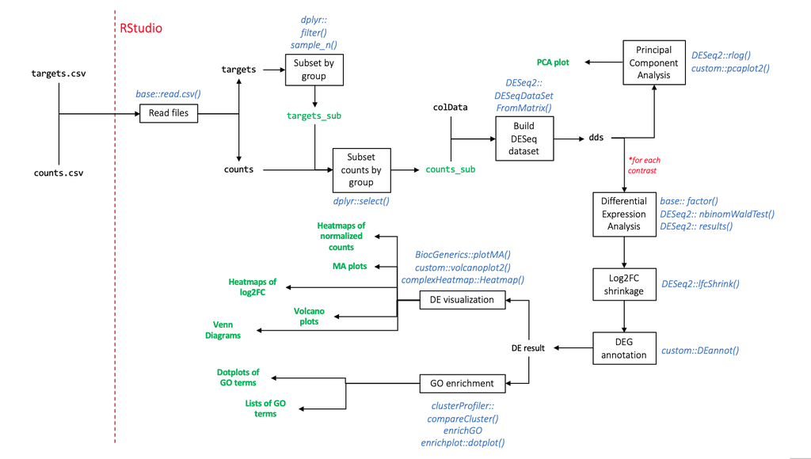

**Figure 1**._**Workflow of the analysis**_. *Black text within boxes represents the steps of the analysis, blue text represents the functions used in each step of the analyses and black text outside of boxes represents the inputs and outputs of each function.*

The code used in all the analyses can be consulted in the code section of the appendix, as well as a more extensive explanation of each step followed in the analyses. In the results section, only some explanations are done in order to follow the analyses in a easier way.

### Steps

The steps of the analysis can be divided in:

**RAW DATA**

1. **Downloading and reading**: downloading the *targets.csv* and *counts.csv* files and, using `read.csv()`, read them and store them in the R environment. Then, format the ENSEMBLE GENE IDS from the *counts* file to remove the version (i.e. **ENSG00000000000**.1)
2. **Subsetting data**: using the R fucntions `filter()` and `sample_n()` from `dplyr`, subset the *targets* file to get 10 samples of each group (*targets_sub*). After that, using the subset of *targets* and the function `select()` from `dplyr`, subset the *counts* in order to get the gene counts in the subseted samples of each group (final counts table: *counts_sub*).

**DE ANALYSIS**

**PCA**

**DE Visualization**

**GO enrichment of DEGs**

14. **GO enrichment**: using the functions `compareCluster()` and `enrichGO()` from `clusterProfiler` we retrieve the enriched GO terms in the up and downregulated genes in each of our contrasts. Then, with the function `dotplot()` from `enrichplot`, draw a dotplot with the enriched GO terms for each of the gene lists.

## Reproducibility

This study can be retrieved from **Github**: https://github.com/amitjavilaventura/OmicsDataAnalysis_PEC2-sequencing

# RESULTS & DISCUSSION

## Raw data

After reading the *target.csv* and *counts.csv* files, the first thing to take into account is the formatting of the gene ID, since its format is ENSEMBL ID and contains the version of the gene annotation at the end of the ID, but it can cause problems in further steps that require to change the gene ID format. Alternatively, we could change the format to SYMBOL in order to have more understandable gene IDs, but in the process some genes are usually lost, so this alternative step won’t be performed.

Then, since we are required to work with only 10 samples from each group, we have to be aware that, specially in the case of the *NIT* condition which has a lot of replicates, the results can vary a lot depending on which replicates we use. To minimize the variation in this case, we must use a seed before subsetting the replicates.

## Differential expression analysis

### Data processing

Before creating the dataset that will be used for the DE analysis with `DESeq2`, we could remove some low expressed genes based on their counts in order to use less memory and increase the computation speed. The filtering is also statistically useful, since the amount of statistical tests that have to be performed is smaller and the adjustment of the p-value is easier, increasing the power of the tests.

Nevertheless, the gene filtering is not performed in our pipline, since DESeq2 has a more stringent filtering step that already increases the statistical power.

We also have to do the contrasts between the different groups/conditions. The contrasts that will be performed are:

- Contrast 1: ELI vs NIT
- Contrast 2: ELI vs SFI
- Contrast 3: SFI vs NIT

After defining the contrasts, thresholds for the adjusted-pvalue and log2FC have to be decided in order to call a gene as differentially expressed gene (DEG). To be called as DEG, a gene has must have an **adjusted p-value <= 0.05** and an absolute value for the **log2FC > 1.5**. The p-value adjustment of DESeq follows a *Benjamini-Hochberg procedure* and it is prefered to use the adjusted p-value instead of the p-value because when multiple testing is performed (like in DE analyses), just by change, some of the tests will result significative when its significance is not correct.

### PCA

The *Principal Component Analysis* (PCA) is a good way to measure the variation between several samples. Normally, it takes the normalized counts of a subset of highly variable genes (i.e. 500 most variable genes) and calculate the variance of these genes using all the samples.

Usually, in a PCA, the replicates from the same condition should cluster together, whereas different conditions can cluster close or far depending on their similarities.

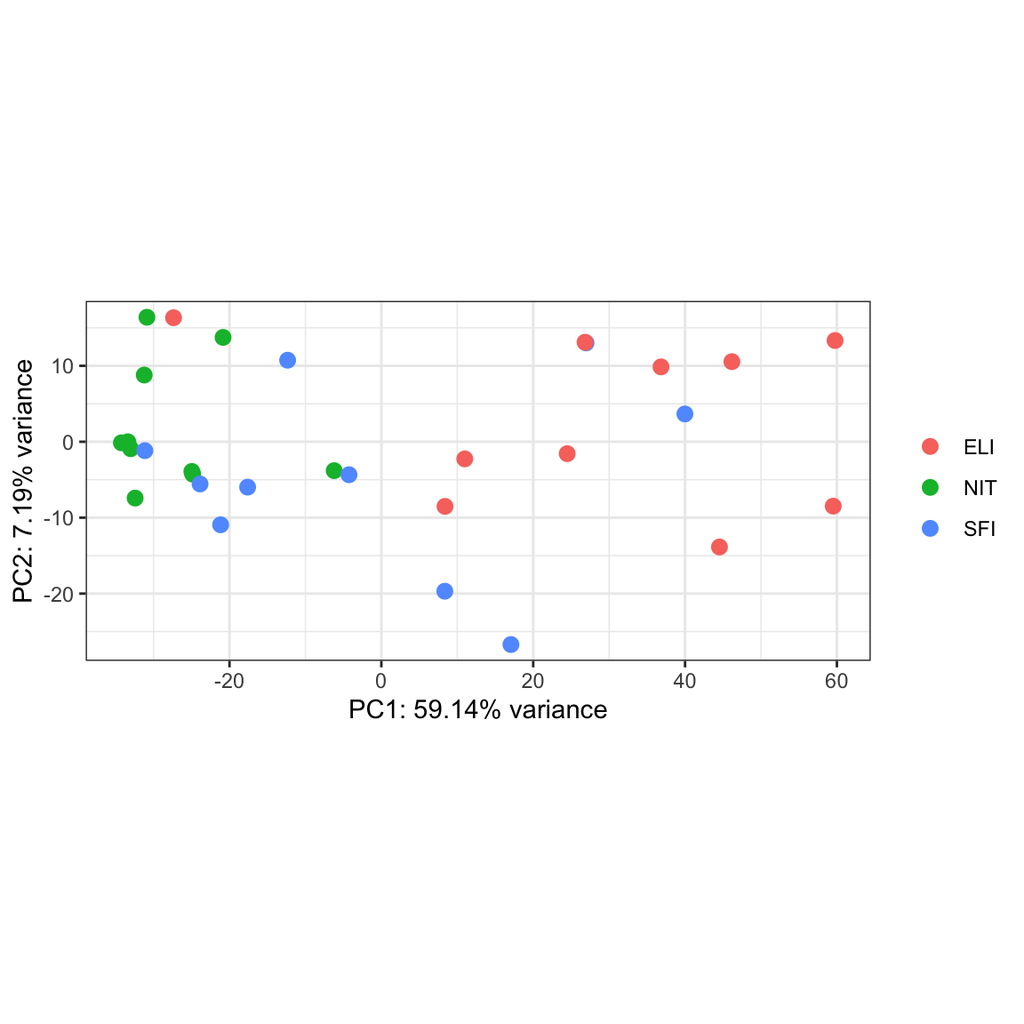

Figure 2. Princiapal component analysis of the 30 samples subtracted (10 replicates for each condition) from the original counts.csv file.

As seen in the *Figure 2*, the samples (even replicates of the same condition) are distributed along all the plot, meaning that there is a lot of variance between them. In the case of the *NIT* and *SFI* replicates, they cluster extremely close to each other in some cases, which suggest that the gene expression in these conditions is very similar. On the other hand, the replicates from *ELI*, despite some of them clustering far from each other, they don’t cluster very close to the other conditions (compared to *NIT* and *SFI*), indicating that *ELI* condition might be the most different compared to three conditions.

### Visualization

To visualize the gene expression, there are several methods:

#### Heatmaps

Heatmaps are a way to visualize different samples or conditions and compare them. They can be used to look at a group of genes and compare different values (i.e. normalized counts, log2FC) between different samples or conditions.

In our case, using all the genes would not be very clever, since most of the genes in a genome are not differentially expressed and wouldn’t make a difference between the samples. Instead, we will take the contrast of *ELI vs NIT*, which is expected to be the one with most DEGs, and will subset the 100 most differentially expressed genes (highest absolute value of log2FC). This list of 100 genes is the one that will be used to compare the different samples.

Alternatively, different gene signatures can be searched in order to have a list of genes that are typical from a determined cell state (i.e. stemness, leukemia, etc).

##### Normalized counts

The normalized counts can be useful either to compare different conditions or to compare intra-condition replicates.

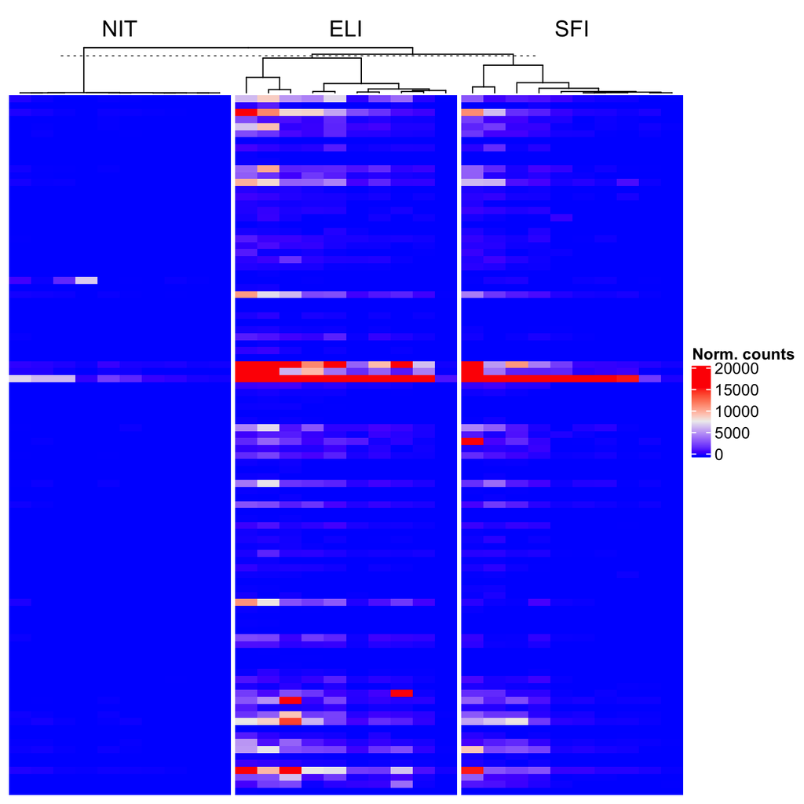

Figure 3. Heatmap with the normalized counts of the 100 most DE genes (ELI vs NIT) with all samples clustered by replicates

##### Log2FCs

Heatmaps of Log2FC are useful to compare the different contrasts.

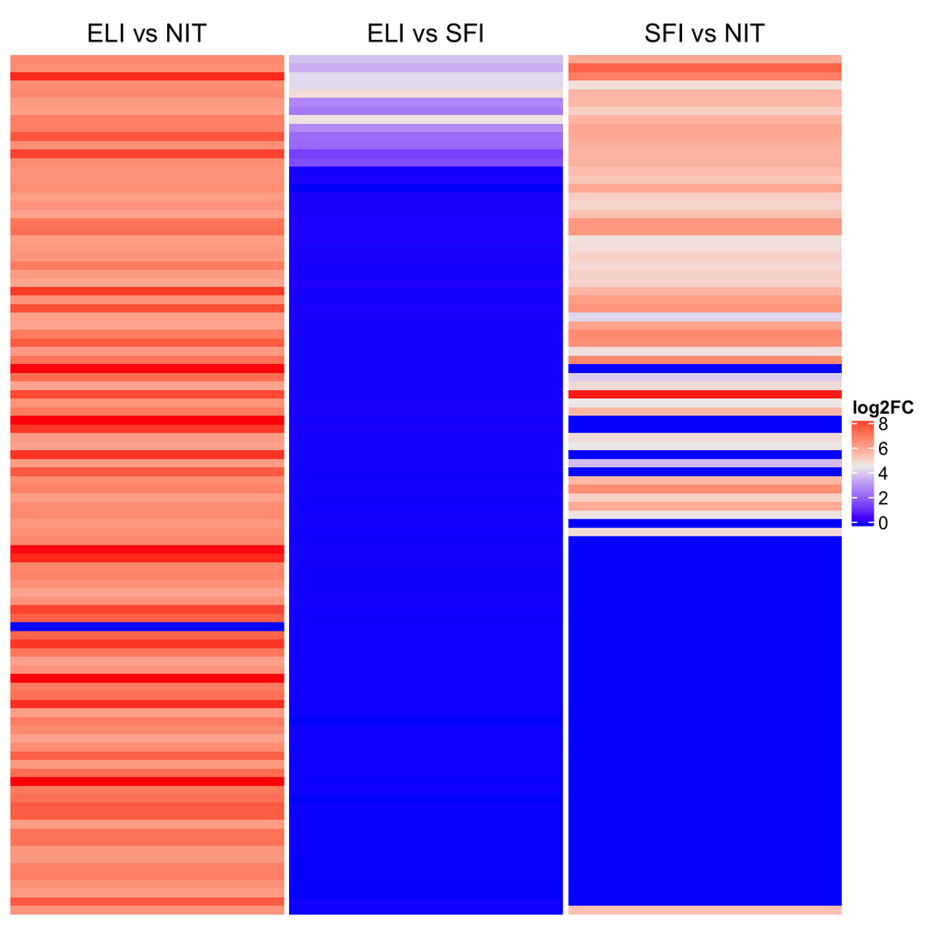

Figure 4. Heatmap with the log2FC of the 100 most DE genes (ELI vs NIT) comparing the three studied contrasts.

```r
#filtering contrasts
contrast1_filt <- contrast1.res_annot[which(contrast1.res_annot$Geneid %in% genes$Geneid),] %>% dplyr::select(log2FoldChange)
contrast2_filt <- contrast2.res_annot[which(contrast2.res_annot$Geneid %in% genes$Geneid),] %>% dplyr::select(log2FoldChange)
contrast3_filt <- contrast3.res_annot[which(contrast3.res_annot$Geneid %in% genes$Geneid),] %>% dplyr::select(log2FoldChange)

#constructing matrix
mat <- data.frame(ELIvsNIT = contrast1_filt$log2FoldChange,
                  ELIvsSFI = contrast2_filt$log2FoldChange,
                  SFIvsNIT = contrast3_filt$log2FoldChange)

#plotting heatmap
h1 <- Heatmap(mat, name = "log2FC", cluster_rows = F, show_row_names = F,
        column_split = c("ELI vs NIT", "ELI vs SFI", "SFI vs NIT"), show_column_names = F)

h1
```

This suggests that upon lymphoid inflitration to the thyrioid, a lot of genes are activated and, since we are talking about lymphoid infiltration, those genes may be putatively related to the immune system.

#### MA plots

MA plots are plots that draw the mean of the normalized counts (between all the replicates in the study) in the X axis and the log2FC of the genes in a determined contrast in the Y axis. This way, a relation between the mean expression and the change in expression from a condition to another can be computed.

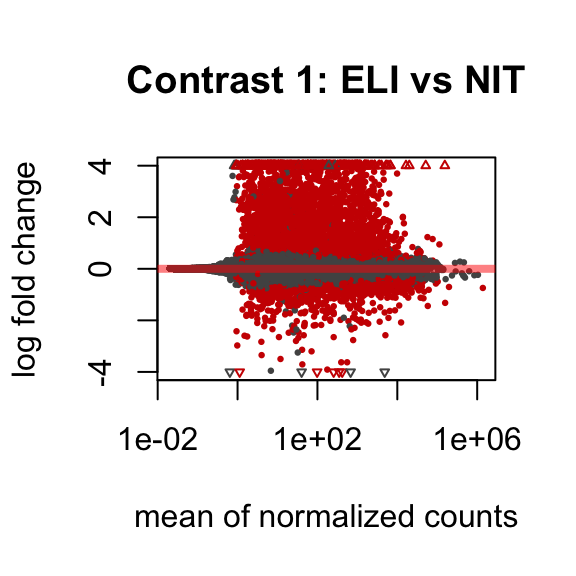

Figure 5. MA plots of the three studied contrasts.

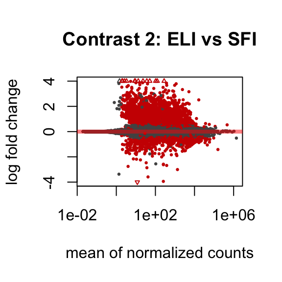

Figure 5. MA plots of the three studied contrasts.

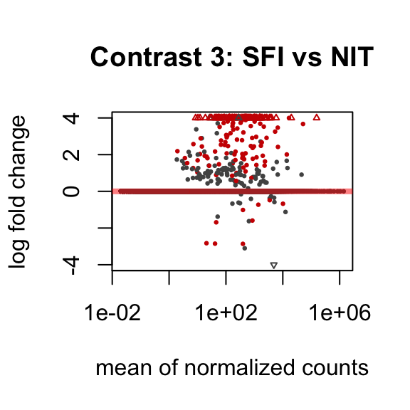

Figure 5. MA plots of the three studied contrasts.

#### Volcano plots

Volcano plots are probably the most useful way to visualize a DE analysis. They draw scatter plot with a point for each gene with the **log2FC** in the X axis and the **-log10 of the adjusted p-value** in the Y axis. Usually, they take a volcano-like shape because the genes with highest log2FC (in absolute value) are also those with more significance (and hence lower p-value). Moreover the color of the points can be set up depending on whether the gene is upregulated, downregulated or not differentially expressed.

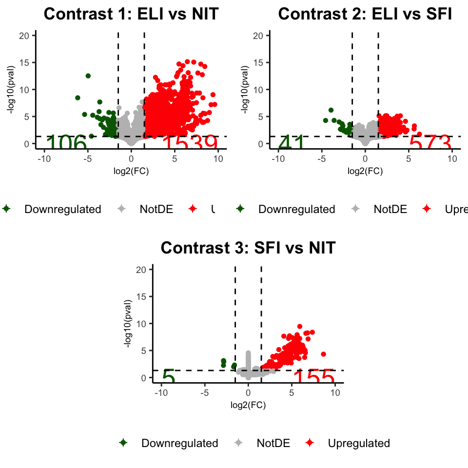

Figure 6. Volcano plots of the different studied contrasts.

The volcano plots in *Figure 6* confirm what has been seen with the MA plots: the conditions *SFI* and *NIT* (contrast 3) are very similar, since there are only a few genes called as differentially expressed. In the contrast 1 and 2, the number of differentially expressed genes (DEGs) is much higher.

Looking at the effects of the lymphoid infiltration (*ELI > SFI > NIT*), it increases the gene expression of a large amount of genes, either in the contrast *ELI vs NIT* or *ELI vs SFI*, whereas the number of downregulated genes is extremely low in comparison with the activated ones.

#### Overlaps

To see how many differentially expressed genes overlap between different contrasts, we can take the lists of gene names (ex. in ensembl id) and, using the custom function `overlapDE()` we will make the intersection of the DEG lists and plot the Venn diagrams. However, first of all we must separate the upregulated and downregulated genes and, to do it, we will use the custom function `subsetDegs()`.

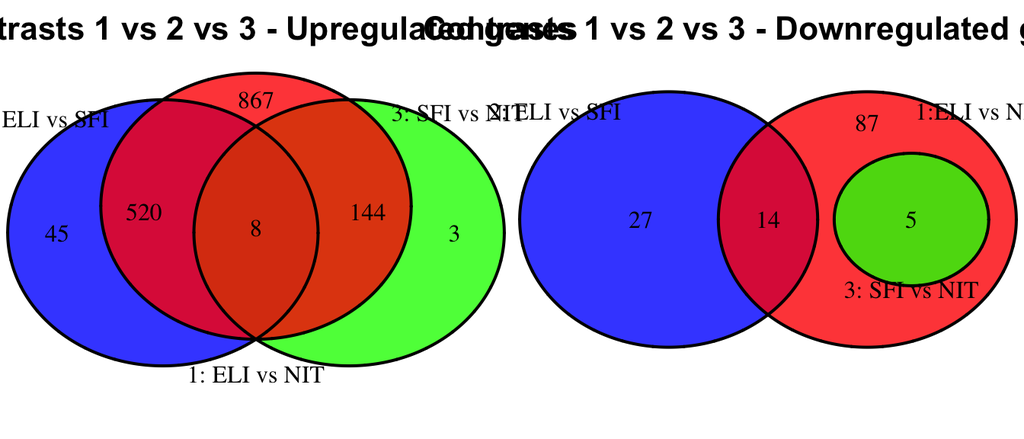

Figure 7. Venn diagrams of the intersections (between the three studied contrasts) of up and downregulated genes

Gene ontology (GO) is a project that looks towars functional annoation of the genes (biological processes, molecular functions, cellular localizations). To look at the GO terms that are enriched in our DE genes is a good way to see what happens in the different samples and conditions.

[figure not shown]

Figure 8. Most enriched GO terms (for biological process) in our contrasts. GO terms have been called with a q-value cutoff of 0.15 amd a p-value cutoff of 0.1

As shown in *Figure 8*, when looking at the upregulated genes, the enriched GO terms are similar in contrasts *ELI vs NIT* and *ELI vs SFI*. As seen in the dotplot, these GO terms (*biological process*) are mainly related to processes of the immune system, such as lymphocyte and leukocyte proliferation or activation.

# CONCLUSION

Neverteless, we should gather more information and perform further studies to make a robust conclusion.

# REFERENCES

1. [GTEx Consortium. **The Genotype-Tissue Expression (GTEx) project**. *Nature Genetics*. 2013 Jun; 45(6):580-5.](https://pubmed.ncbi.nlm.nih.gov/23715323/?from_single_result=23715323%5BPMID%5D&expanded_search_query=23715323%5BPMID%5D)
2. [Love, M.I., Huber, W., Anders, S. **Moderated estimation of fold change and dispersion for RNA-seq data with DESeq2**. *Genome Biology* 15(12):550 (2014)](https://genomebiology.biomedcentral.com/articles/10.1186/s13059-014-0550-8)

# APPENDIX

## Code

### Raw data

#### Read files

After downloading the files, we read them using the function `read.csv()`. Then, using `str_sub()` from the package `stringr` we modify the rownames from the *counts* file in orther to get the ENSEMBL ID without the version (*i.e. ENSG00000000000.1 to ENSG00000000000*).

```r
#read files from counts
targets <- read.csv(file = "targets_counts/targets.csv", header = T, sep = ",")
counts  <- read.csv(file = "targets_counts/counts.csv", header = T, sep = ";", row.names = 1)

#format rownames of the counts file
ensemblID <- rownames(counts) %>% stringr::str_sub(start = 1, end = 15)
ensemblID -> rownames(counts)

#get gene symbols
genesymbols <- bitr(ensemblID, fromType = "ENSEMBL", toType = "SYMBOL", OrgDb = org.Hs.eg.db)
#genesymbols$SYMBOL %>% length()
```

#### Filter samples

Once the gene ids have been formatted, we proceed to subset the *targets* in order to get 10 random samples from each group (NIT, SFI and ELI). Then, using this subset of *targets* (*targets_sub*), we can proceed to subset the *counts* in order to get all gene counts in the 30 samples present in *targets_sub*. Notice that the sample names in *targets_sub* do not have the same format as the ones in *counts*, so we will have to replace the “-” for “.” in *targets_sub* using the function `gsub()`.

Alternatively, we can use `bitr()` function from `clusterProfiler` to change the gene names from ENSEMBL ID to SYMBOL in order to get more understandable gene names. Nevertheless, by doing that we lose more than half of the genes, so we will not change it and we will proceed with the ENSEMBL ID.

```r
#set seed for the random subsetting
set.seed(972)

#subset targets by group (10 samples from each group)
targets_sub <- rbind(targets %>% filter(Group=="NIT") %>% sample_n(size = 10),
                     targets %>% filter(Group=="SFI") %>% sample_n(size = 10),
                     targets %>% filter(Group=="ELI") %>% sample_n(size = 10)) %>%

  mutate(Sample_Name = Sample_Name %>% gsub(pattern = "-", replacement = "."))

#subset counts by samples in targets_sub
counts_sub  <- counts[,targets_sub$Sample_Name]

#write files with targets sub and counts sub
write.table(x = targets_sub, file = "results/targets_sub.tsv", quote = F, sep = "\t", col.names = T)
write.table(x = counts_sub %>% mutate(GeneID = rownames(counts_sub)), file = "results/counts_sub.tsv", quote = F, sep = "\t", col.names = T)
```

### Differential expression analysis

To do the differential expression (DE) analysis we can use several packages, such as `limma`-`voom`, `edgeR` or `DESeq2`, etc. In our case, the package used will be `DESeq2` [^2^](#2).

`DESeq2` takes the raw counts of each gene and calculates the dispersion of the gene expression using all the replicates in each condition. Then, it calculates the size factors in order to normalize the data and fits the data to a model. Finally, `DESeq2` performs a **Negative Binomial Wald Test** to determine the fold-changes, their base-2 logarithms (**log2FC**), the p-values and the **adjusted p-values** of each gene in each of the comparisons made. Externally, we will use a package named `apeglm` to produce the srinkage of the log2FC.

#### Data processing

We already have the raw counts in *counts_sub*, however we need a table with the information of the samples (named *colData*), where we will write the sample names (*Sample_Name* in *targets_sub*) and their correspondent group (*Group* in *targets_sub*). After that, if the column names in *counts_sub* are equal to the row names of *colData* we will proceed to get the DESeq dataset using `DESeqDataSetFromMatrix()`.

```r
#create colData with samplenames and the group
colData <- targets_sub %>% dplyr::select(Sample_Name, Group) %>% tibble::column_to_rownames(var = "Sample_Name") %>% magrittr::set_colnames("condition")

# if colnames of counts_sub are equal to the rownames of colData, continue to get the DESeq dataset
if(colnames(counts_sub) == rownames(colData)){

  dds <- DESeq2::DESeqDataSetFromMatrix(countData = counts_sub,
                                      colData = colData,
                                      design = ~condition)

}
```

Once we have the DESeq dataset, we use `DESeq()` from `DESeq2` to get the estimates of size factors and dispersions and then fits the data to a model.

Using other methods, one would filter the genes based on their counts (i.e. those genes with less than 10 counts in all samples would be filtered out). However, with `DESeq2` we don’t do that because `DESeq2` already performs a more stringent filtering with the `results()` function in order to increase the power of the tests and to reduce the number of tests to perform.

```r
#DESeq() function
# dds <- DESeq(dds)

#DESeq() function is equivalent to the following three funtions:
dds <- estimateSizeFactors(dds)
dds <- estimateDispersions(dds)
dds <- nbinomWaldTest(dds) #this one will be repeated for each contrast, so it is not absolutelly necessary here


#write normalized counts
norm_counts <- counts(dds, normalized=T) %>% as.data.frame() %>% round(3) %>% tibble::rownames_to_column("GeneID")

#save dds object so we can continue from here next time
saveRDS(dds, file = "results/deseq.rds")
```

Now we have to do the contrasts between the different groups/conditions. The contrasts that will be performed are:

- Contrast 1: ELI vs NIT
- Contrast 2: ELI vs SFI
- Contrast 3: SFI vs NIT

First we relevel the conditions in order to get the correct contrasts. Then, using `nbinomWaldTest()`, we perform the multiple testing to see how gene expressions change from one condition to another one. Using the function `results()`, results tables are generated, getting the log2FC and the corresponding (adjusted-) pvalue for each gene in each contrast. Finally, the results are passed through `lfcShrink()` in order to produce the log2FC shrinkage specifying the method “apeglm” from the package `apeglm`.

```r
# ---- CONTRAST 1 ---- #
contrast1 <- c("condition", "ELI", "NIT")
contrast1.dds <- dds

# relevel conditions
contrast1.dds$condition <- factor(contrast1.dds$condition, levels = c("NIT", "ELI", "SFI"))

# statistical testing
contrast1.dds <- nbinomWaldTest(contrast1.dds)

# getting results
contrast1.res <- results(contrast1.dds, contrast = contrast1)

#log2FC shrinkage
contrast1.res <- lfcShrink(dds = contrast1.dds, coef = "condition_ELI_vs_NIT", res = contrast1.res, type = "apeglm")


# ---- CONTRAST 2 ---- #
contrast2 <- c("condition", "ELI", "SFI")
contrast2.dds <- dds

# relevel conditions
contrast2.dds$condition <- factor(contrast2.dds$condition, levels = c("SFI", "ELI", "NIT"))

# statistical testing
contrast2.dds <- nbinomWaldTest(contrast2.dds)

# getting results
contrast2.res <- results(contrast2.dds, contrast = contrast2)

#log2FC shrinkage
contrast2.res <- lfcShrink(dds = contrast2.dds, coef = "condition_ELI_vs_SFI", res = contrast2.res, type = "apeglm")


# ---- CONTRAST 3 ---- #
contrast3 <- c("condition", "SFI", "NIT")
contrast3.dds <- dds

# relevel conditions
contrast3.dds$condition <- factor(contrast3.dds$condition, levels = c("NIT", "SFI", "ELI"))

# statistical testing
contrast3.dds <- nbinomWaldTest(contrast3.dds)

# getting results
contrast3.res <- results(contrast3.dds, contrast = contrast3)

#log2FC shrinkage
contrast3.res <- lfcShrink(dds = contrast3.dds, coef = "condition_SFI_vs_NIT", res = contrast3.res, type = "apeglm")
```

```r
contrast1.res_annot <- contrast1.res[order(contrast3.res$padj),] %>%
  data.frame() %>% tibble::rownames_to_column(var = "Geneid")

contrast2.res_annot <- contrast2.res[order(contrast2.res$padj),] %>%
  data.frame() %>% tibble::rownames_to_column(var = "Geneid")

contrast3.res_annot <- contrast3.res[order(contrast3.res$padj),] %>%
  data.frame() %>% tibble::rownames_to_column(var = "Geneid")
```

Now, using the custom function `DEannot()` we will assing each gene as upregulated, downregulated or not differentially expressed (custom functions can be consluted in the GitHub repository). To be called as differentially expressed (either up or downregulated), a gene has to hava an adjusted **p-value lower than 0.05** and an **absolute value of log2FC greater than 1.5** (which means that the expression has been increased or decreased by 2.8284271 times). Alternatively, we can also use `bitr()` to change the EnsemblID to GeneSymbol in order to get more understandable gene names.

```r
contrast1.res_annot <- DEannot(contrast1.res_annot)
contrast2.res_annot <- DEannot(contrast2.res_annot)
contrast3.res_annot <- DEannot(contrast3.res_annot)
```

```r
dir.create(path = "results/deseq2", showWarnings = F, recursive = T)
write.table(contrast1.res_annot, file = "results/deseq2/eli_vs_nit-diff_exp.tsv", quote = F, sep = "\t", row.names = F)
write.table(contrast2.res_annot, file = "results/deseq2/eli_vs_sfi-diff_exp.tsv", quote = F, sep = "\t", row.names = F)
write.table(contrast3.res_annot, file = "results/deseq2/sfi_vs_nit-diff_exp.tsv", quote = F, sep = "\t", row.names = F)
```

#### PCA

In order to see how the replicates of each condition are related between them, we can do a principal component analysis (PCA).

First of all, using the *dds* object, we take the counts and perform a *rlog transformation* with the function `rlog()`. After that, using the function `pcaplot()` from the R package `pcaExplorer` we draw the dotplot of the principal component analysis (package `pcaExplorer` cannot be loaded, so we will use a modification of `pcaplot()` called `pcaplot2()`).

```r
rlog_counts <- rlog(dds, blind = FALSE)
```

```
pca <- pcaplot2(rlog_counts, intgroup = "condition", ellipse = F, text_labels = F)
```

#### Visualization

##### Heatmaps

Using the R package `ComplexHeatmap` we can draw heatmaps comparing the samples or the conditions we wish.

###### Normalized counts

A good thing we can do is to build a heatmap with the normalized counts of the most differentially expressed genes (100 genes) in the contrast *ELI vs NIT*. This way, we can look visually at the differences between the different conditions and whether the intra-condition replicates are similar regarding the expression of these genes.

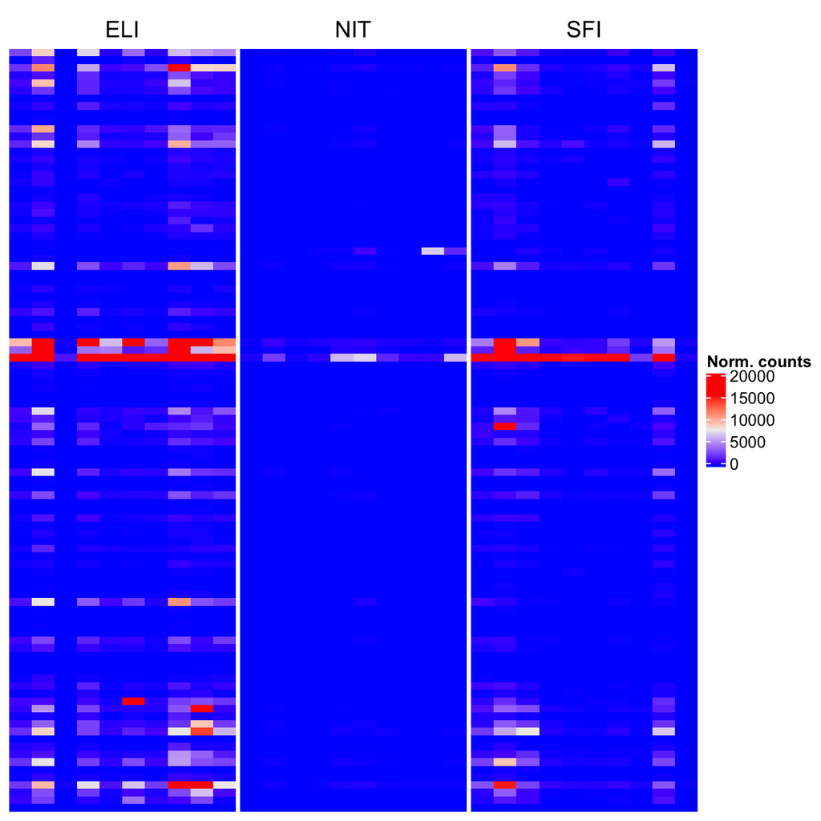

```r
#get 1000 genes more differentially expressed in the first contrasts
genes <- contrast1.res_annot %>%
  mutate(abs_log2FC = abs(log2FoldChange)) %>% arrange(desc(abs_log2FC)) %>% dplyr::select(Geneid) %>% head(100)

#filter normalized counts
norm_counts_filt <- norm_counts[which(norm_counts$GeneID %in% genes$Geneid),] %>% dplyr::select(c(2:31))

#create heatmap fo normalized counts for the 1000 most differntially expressed genes
h0 <- Heatmap(norm_counts_filt,
              cluster_rows = F, cluster_columns = F,
              show_row_names = F, show_column_names = F,
              column_split = c(rep("NIT",10), rep("SFI",10), rep("ELI",10)),
              name = "Norm. counts", heatmap_width = 5)
h0
```

###### Log2FCs

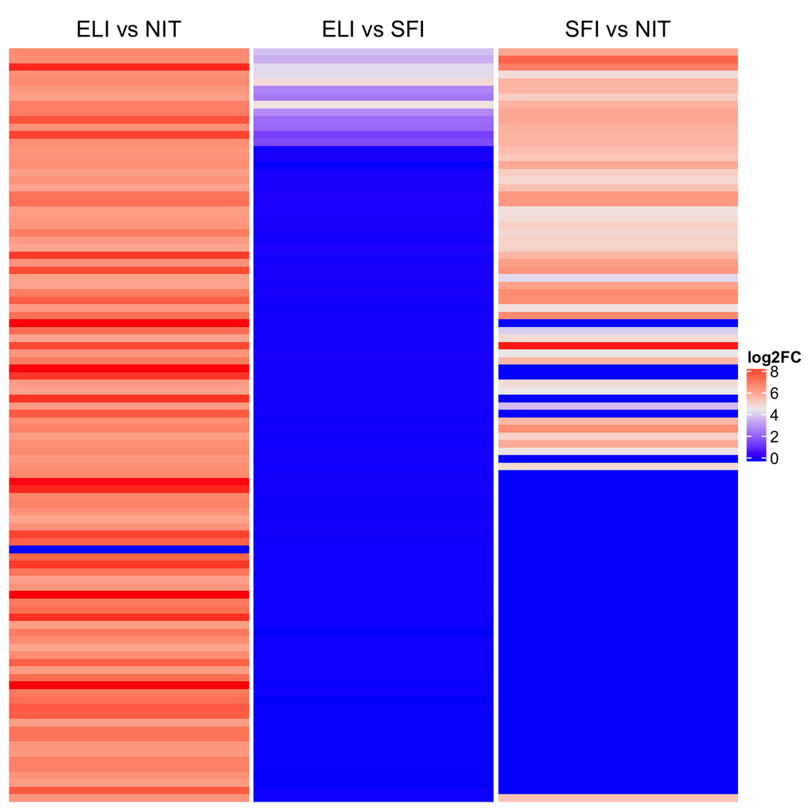

```r
#get 100 genes more differentially expressed in the first contrasts
genes <- contrast1.res_annot %>%
  mutate(abs_log2FC = abs(log2FoldChange)) %>% arrange(desc(abs_log2FC)) %>% dplyr::select(Geneid) %>% head(100)

contrast1_filt <- contrast1.res_annot[which(contrast1.res_annot$Geneid %in% genes$Geneid),] %>% dplyr::select(log2FoldChange)
contrast2_filt <- contrast2.res_annot[which(contrast2.res_annot$Geneid %in% genes$Geneid),] %>% dplyr::select(log2FoldChange)
contrast3_filt <- contrast3.res_annot[which(contrast3.res_annot$Geneid %in% genes$Geneid),] %>% dplyr::select(log2FoldChange)

mat <- data.frame(ELIvsNIT = contrast1_filt$log2FoldChange,
                  ELIvsSFI = contrast2_filt$log2FoldChange,
                  SFIvsNIT = contrast3_filt$log2FoldChange)


h1 <- Heatmap(mat, name = "log2FC", cluster_rows = F, show_row_names = F,
        column_split = c("ELI vs NIT", "ELI vs SFI", "SFI vs NIT"), show_column_names = F)

h1
```

##### MA plots

One of the things we can do to see the DE analysis results is a MA plot, which draws the mean of the normalized counts in the X axis against the log2FC in the Y axis. A useful function to draw MA plots is `plotMA()` from `BiocGenerics` package.

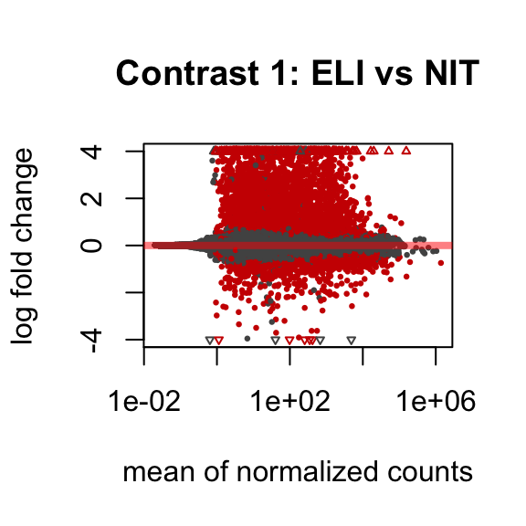

```r
contrast1.ma <- plotMA(contrast1.res, main = "Contrast 1: ELI vs NIT", ylim = c(-4,4))
```

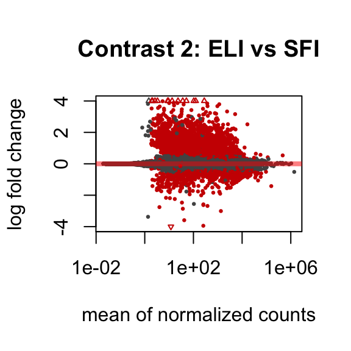

```r
contrast2.ma <- plotMA(contrast2.res, main = "Contrast 2: ELI vs SFI", ylim = c(-4,4))
```

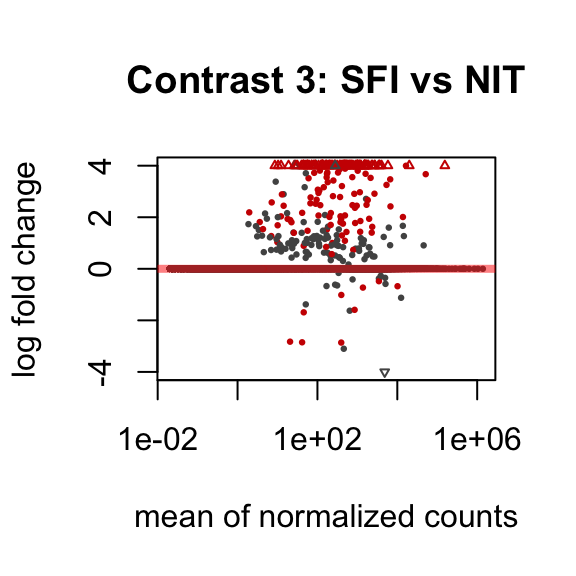

```r
contrast3.ma <- plotMA(contrast3.res, main = "Contrast 3: SFI vs NIT", ylim = c(-4,4))
```

Looking at the MA plots, it is easy to say that the SFI and NIT conditions (contrast 3: SFI vs NIT) are very similar in terms of gene expression, since most of the genes in the contrast are aligned in a log2FC value of 0, regardless of the gene expression (mean of the normalized counts). In the other two contrasts, there are more genes with a log2FC of 1 (which mean that the gene expression has increased to the the double or decresed to the half).

##### Volcano plots

Probably, the most useful way to visualize a DE analysis is through **volcano plots**, which draw a point for each gene with the log2FC in the X axis and the -log10(adjusted pvalue) in the Y axis. Usually, the color of the points depends on whether the gene is upregulated, downregulated or not differentially expressed.

To draw the volcano plots we will use a custom function named `VolcanoPlot2()`.

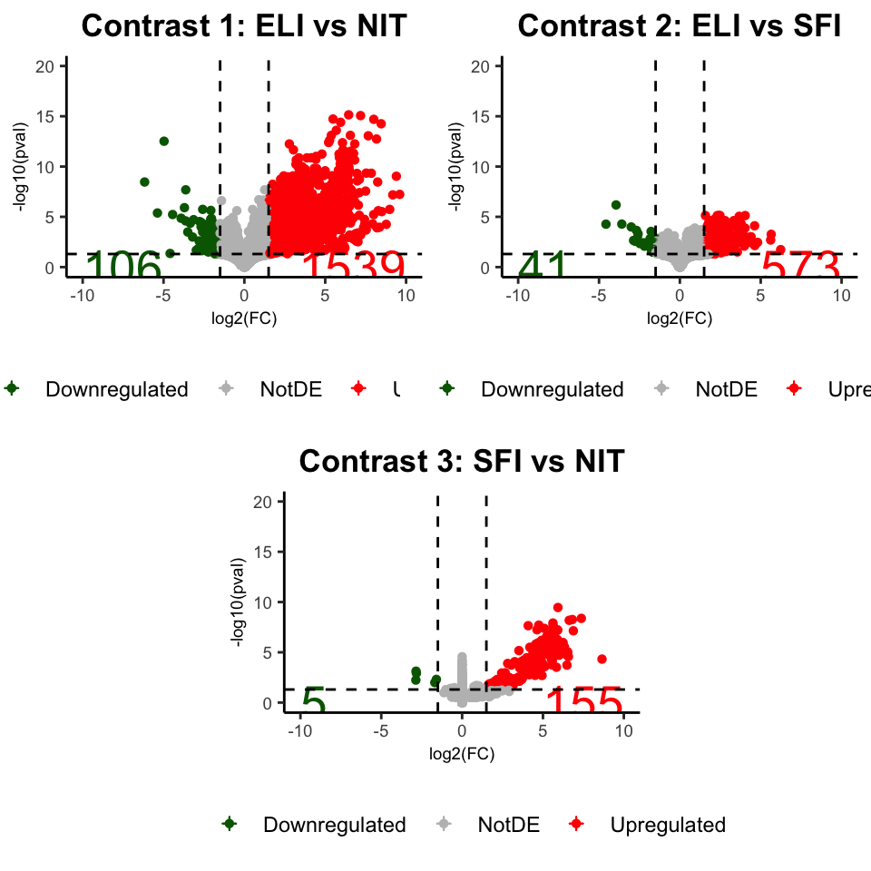

```r
contrast1.volcano <- VolcanoPlot2(dataframe = contrast1.res_annot, ylim = c(0,20), main = "Contrast 1: ELI vs NIT", title_size = 13, degsLabel = F)
contrast2.volcano <- VolcanoPlot2(dataframe = contrast2.res_annot, ylim = c(0,20), main = "Contrast 2: ELI vs SFI", title_size = 13, degsLabel = F)
contrast3.volcano <- VolcanoPlot2(dataframe = contrast3.res_annot, ylim = c(0,20), main = "Contrast 3: SFI vs NIT", title_size = 13, degsLabel = F)

ggdraw() +
  draw_plot(contrast1.volcano, x = .25, y = .75, width = .5, height = .5, vjust = .5, hjust = .5) +
  draw_plot(contrast2.volcano, x = .75, y = .75, width = .5, height = .5, vjust = .5, hjust = .5) +
  draw_plot(contrast3.volcano, x = .50, y = .25, width = .5, height = .5, vjust = .5, hjust = .5)
```

Looking at the effects of the lymphoid infiltration, it increases the gene expression of a large amount of genes, either in the contrast *ELI vs NIT* or *ELI vs SFI*, whereas the number of downregulated genes is extremely low in comparison with the activated ones.

##### Overlaps

To see how many and which differentially expressed genes overlap between different contrast, we can take the lists of gene names (ex. in ensembl id) and, using the custom function `overlapDE()` we will make the intersection of the DEG lists and plot the Venn diagrams. However, first of all we must separate the upregulated and downregulated genes and, to do it, we will use the custom function `subsetDegs()`.

```r
#subset degs
contrast1_degs <- subsetDegs(contrast1.res_annot)
contrast2_degs <- subsetDegs(contrast2.res_annot)
contrast3_degs <- subsetDegs(contrast3.res_annot)

venn_123_up   <- overlapDE3(contrast1_degs$up, contrast2_degs$up, contrast3_degs$up,
                            categories = c("1: ELI vs NIT", "2: ELI vs SFI", "3: SFI vs NIT"))
venn_123_down <- overlapDE3(contrast1_degs$down, contrast2_degs$down, contrast3_degs$down,
                            categories = c("1:ELI vs NIT", "2: ELI vs SFI", "3: SFI vs NIT"))
```

[figure not shown]

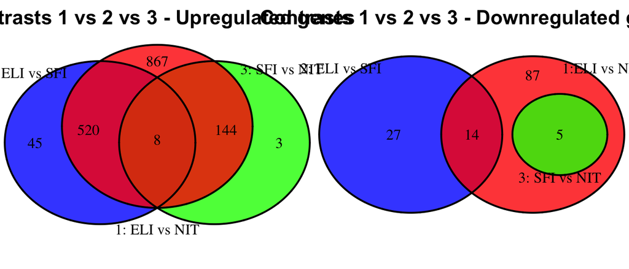

```r
ggdraw() +
  draw_plot(venn_123_up, x = .25, width = .5, hjust = .5) +
  draw_plot(venn_123_down, x = .75, width = .5, hjust = .5) +
  draw_plot_label(label = "Contrasts 1 vs 2 vs 3 - Upregulated genes", x = .25, hjust = .5, y = 0.99, size = 16) +
  draw_plot_label(label = "Contrasts 1 vs 2 vs 3 - Downregulated genes", x = .75, hjust = .5, y = 0.99, size = 16)
```

Another intersting thing to do is an analysis of the GO terms related to the up and downregulated genes (separately). To do so, we will use the R package `clusterProfiler`.

First, we need to separate the upregulated and downregulated genes from each contrast, take the list of gene IDs and then format them to ENTREZ ID. This process will make us lose some of the genes.

```r
#separate DEGs in up or downregulated genes
contrast1_up   <- contrast1.res_annot %>% filter(DEG == "Upregulated") %>% dplyr::select(Geneid)
contrast1_down <- contrast1.res_annot %>% filter(DEG == "Downregulated") %>% dplyr::select(Geneid)
contrast2_up   <- contrast2.res_annot %>% filter(DEG == "Upregulated") %>% dplyr::select(Geneid)
contrast2_down <- contrast2.res_annot %>% filter(DEG == "Downregulated") %>% dplyr::select(Geneid)
contrast3_up   <- contrast3.res_annot %>% filter(DEG == "Upregulated") %>% dplyr::select(Geneid)
contrast3_down <- contrast3.res_annot %>% filter(DEG == "Downregulated") %>% dplyr::select(Geneid)

#convert gene names from ensembl id to entrez id
contrast1_up   <- bitr(contrast1_up$Geneid, fromType = "ENSEMBL", toType = "ENTREZID", OrgDb = org.Hs.eg.db)
contrast1_down <- bitr(contrast1_down$Geneid, fromType = "ENSEMBL", toType = "ENTREZID", OrgDb = org.Hs.eg.db)
contrast2_up   <- bitr(contrast2_up$Geneid, fromType = "ENSEMBL", toType = "ENTREZID", OrgDb = org.Hs.eg.db)
contrast2_down <- bitr(contrast2_down$Geneid, fromType = "ENSEMBL", toType = "ENTREZID", OrgDb = org.Hs.eg.db)
contrast3_up   <- bitr(contrast3_up$Geneid, fromType = "ENSEMBL", toType = "ENTREZID", OrgDb = org.Hs.eg.db)
contrast3_down <- bitr(contrast3_down$Geneid, fromType = "ENSEMBL", toType = "ENTREZID", OrgDb = org.Hs.eg.db)
```

```r
go.names <- as.data.frame(c(contrast1_up$ENTREZ, contrast1_down$ENTREZ,
                            contrast2_up$ENTREZ, contrast2_down$ENTREZ,
                            contrast3_up$ENTREZ, contrast3_down$ENTREZ)) %>%
  set_colnames("ENTREZ")
go.names$condition <- c(rep("ELI vs NIT - Up", length(contrast1_up$ENTREZ)),
                        rep("ELI vs NIT - Down", length(contrast1_down$ENTREZ)),
                        rep("ELI vs SFI - Up", length(contrast2_up$ENTREZ)),
                        rep("ELI vs SFI - Down", length(contrast2_down$ENTREZ)),
                        rep("SFI vs NIT - Up", length(contrast3_up$ENTREZ)),
                        rep("SFI vs NIT - Down", length(contrast3_down$ENTREZ)))

go.dot <- compareCluster(data = go.names,
                         geneClusters = ENTREZ~condition,
                         fun = "enrichGO",
                         OrgDb = org.Hs.eg.db,
                         keyType = 'ENTREZID',
                         ont = "BP",
                         pAdjustMethod = "BH",
                         pvalueCutoff = 0.1,
                         qvalueCutoff = 0.15,
                         readable = TRUE)


#list <- list("ELI vs NIT - Down" = go.dot@compareClusterResult %>% dplyr::filter(Cluster == "ELI vs NIT - Down") %>% add_row(),
#             "ELI vs NIT - Up" = go.dot@compareClusterResult %>% dplyr::filter(Cluster == "ELI vs NIT - Up") %>% add_row(),
#             "ELI vs SFI - Down" = go.dot@compareClusterResult %>% dplyr::filter(Cluster == "ELI vs SFI - Down") %>% add_row(),
#             "ELI vs SFI - Up" = go.dot@compareClusterResult %>% dplyr::filter(Cluster == "ELI vs SFI - Up") %>% add_row())

#dir.create(path = "results/GO/", showWarnings = F, recursive = T)
#write.xlsx(x = list, file = "results/GO/GOterms_in_DEGs.xlsx")
```

[figure not shown]

```r
enrichplot::dotplot(object = go.dot, title = "GO terms enriched in the DE genes", showCategory = 20, color = "p.adjust", font.size = 10, split = F) + theme(axis.text.x = element_text(angle = 30, hjust = 1, vjust = 0.9))
```

When looking at the upregulated genes, the enriched GO terms are similar in contrasts *ELI vs NIT* and *ELI vs SFI*. As seen in the dotplot, these GO terms (*biological process*) are mainly related to processes of the immune system, such as lymphocyte and leukocyte proliferation or activation.